# STA207 Hw6 - Eric Kalosa-Kenyon

```r
library("gplots")           # pretty plotting
library("plyr")             # data.frame manipulation
library("gdata")            # reads .xlsx
library("additivityTests")  # interaction plots
library("multcomp")         # multiple comparison tests
```

# 14.9

## 14.9.a

```r
df = read.xls("PR14.9.xlsx", sheet = 1, header = TRUE)
df$Ability = as.factor(df$Ability)
fit = with(df, glm(formula = Ability ~ Stability, family = binomial))
```

The model coefficients are $\beta_0=-10.3089252$ and $\beta_1=0.0189198$.  
The response function is $f(X_i)=\frac{e^{\beta_0 + \beta_1 X_i}}{1+e^{\beta_0 + \beta_1 X_i}}$

## 14.9.b

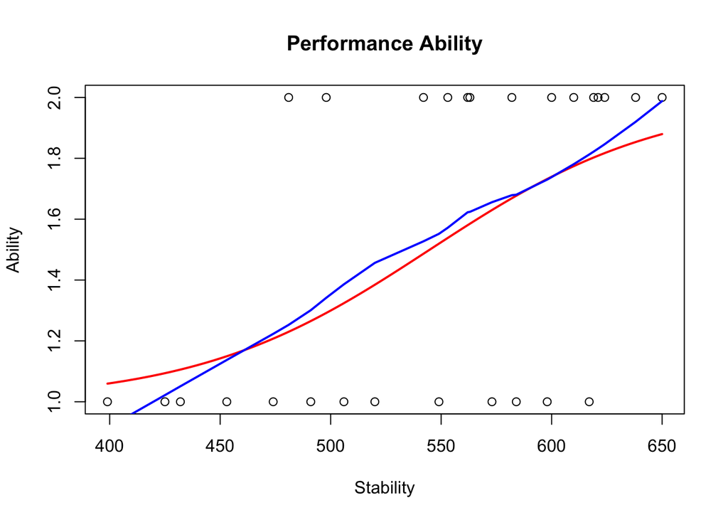

```r
plot(df$Stability, df$Ability, main="Performance Ability",
     xlab="Stability", ylab="Ability")
predProbs=with(df, predict.glm(fit,
    data.frame(Stability=seq(min(Stability), max(Stability), length.out=100)),
    type="response"))
lines(with(df, seq(min(Stability), max(Stability), length.out=100)),
      predProbs+1, lwd=2, col="red") # binomial model
lines(lowess(df$Stability, df$Ability),
      lwd=2, col="blue") # lowess line
```

The red line is the fitted logistic model. The blue line is the Lowess line. The logistic model appears to fit well.

## 14.9.c

$e^{\beta_1}=1.0190999$. This number is the odds ratio of successive values of the signal variable $X_i$. That is, $f(X_i+1)=f(X_i)*e^{\beta_1}$. Another way to interpret this number is that one must increase $X_i$ by $\frac{\log(2)}{\beta_1}=36.6360164$ to double the liklihood of the response being positive.

## 14.9.d

The fitted likelihood of an employee with an emotional stability score of $550$ is $f(550)=0.5242263$.

## 14.9.e

Inverting and solving the logistic regression, we look for $X$ such that $\frac{0.7}{1-0.7}=e^{\beta_0+\beta_1*X}$ which turns out to be $X=\frac{\log(\frac{0.7}{0.3})-\beta_0}{\beta_1}= 589.6576978$. So we would expect that, of those employees with the aforecalculated emotional stability score, $70$% of them would be able to complete the task.

# 14.11

## 14.11.a

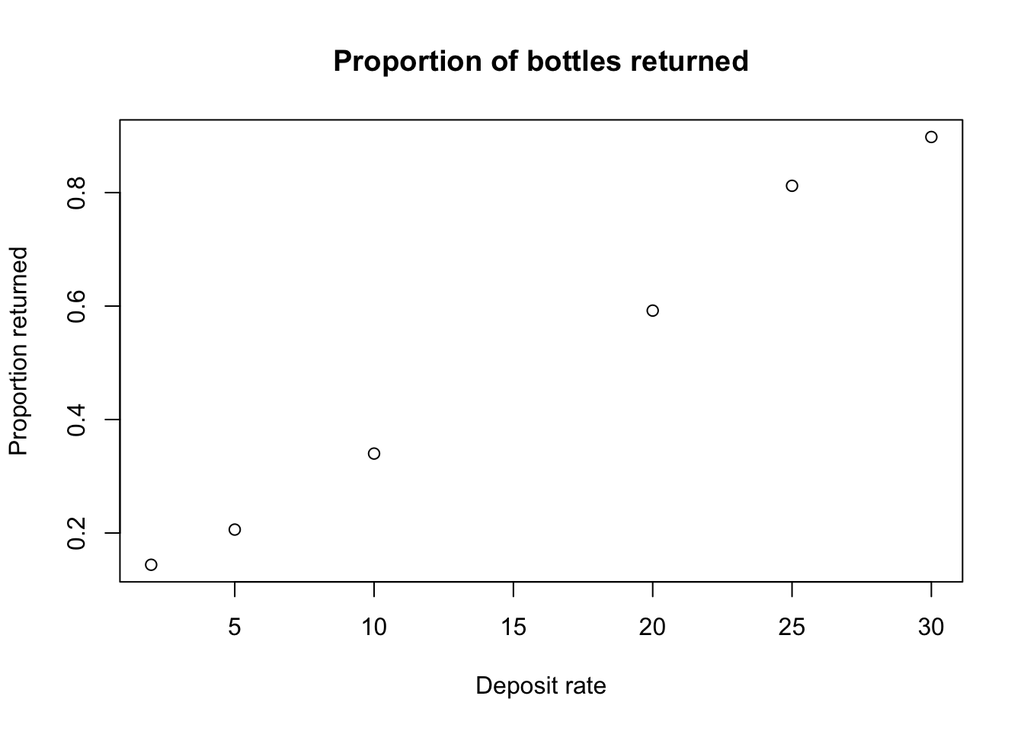

```r
dep = c(2, 5, 10, 20, 25, 30)
sold = c(500, 500, 500, 500, 500, 500)
returned = c(72, 103, 170, 296, 406, 449)
proportion = returned/sold
df = data.frame(
    Deposit=dep, Sold=sold, Returned=returned, Proportion=proportion)
with(df, plot(Deposit, Proportion, main="Proportion of bottles returned",
              xlab="Deposit rate", ylab="Proportion returned"))
```

The visual similarity of the relationship between proportional response and deposit rate to the logistic curve indicates that the logistic model is appropriate here.

## 14.11.b

```r
fit = with(df, glm(formula = Proportion ~ Deposit, family = binomial))
```

The model coefficients are $\beta_0=-2.0765647$ and $\beta_1=0.1358508$.  
The response function is $f(X_i)=\frac{e^{\beta_0 + \beta_1 X_i}}{1+e^{\beta_0 + \beta_1 X_i}}$

## 14.11.c

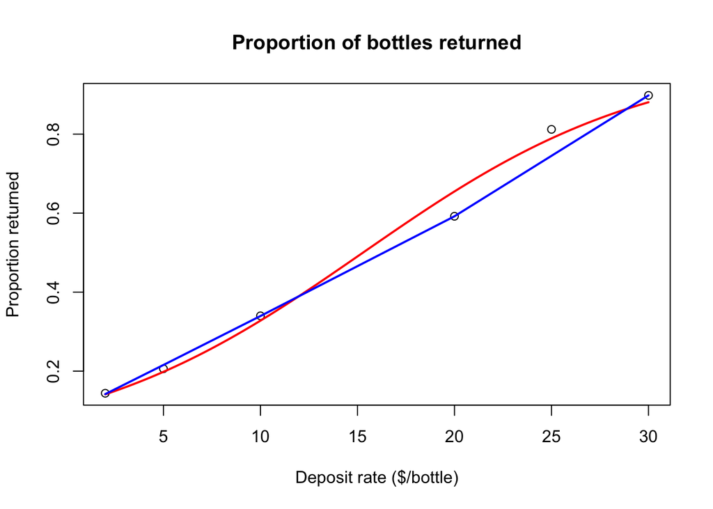

```r
plot(df$Deposit, df$Proportion, main="Proportion of bottles returned",
     xlab="Deposit rate ($/bottle)", ylab="Proportion returned")
predProbs=with(df, predict.glm(fit,
    data.frame(Deposit=seq(min(Deposit), max(Deposit), length.out=100)),
    type="response"))
lines(with(df, seq(min(Deposit), max(Deposit), length.out=100)),
      predProbs, lwd=2, col="red") # binomial model
lines(lowess(df$Deposit, df$Proportion),
      lwd=2, col="blue") # lowess line
```

The red line is the fitted logistic model. The blue line is the Lowess line. The logistic model appears to fit well.

## 14.11.d

$e^{\beta_1}=1.1455109$. This number is the odds ratio of successive values of the signal variable $X_i$. That is, $f(X_i+1)=f(X_i)*e^{\beta_1}$. Another way to interpret this number is that one must increase $X_i$ by $\frac{\log(2)}{\beta_1}=5.1022687$ to double the liklihood of the response being positive.

## 14.11.e

The probability a bottle will be returned when the deposit rate is $15$ cents is $f(15)=0.4903005$.

## 14.11.f

The deposit rate for which $75$% of bottles will be returned is $\frac{\log(\frac{.75}{.25})-\beta_0}{\beta_1}= 23.372534$ cents.

# 14.14

## 14.14.a

```r
df = read.xls("PR14.14.xlsx", sheet = 1, header = TRUE)
fit = with(df,
    glm(formula = Flu.shot ~ Age + Awareness + Gender,
    family = binomial))
```

The model coefficients are $\beta_0=-1.1771592$, $\beta_1=0.072788$, $\beta_2=-0.0989865$, $\beta_3=0.4339749$.

The response function is $f(X_i)= \frac{e^{\beta_0 + \beta_1 X_{1i} + \beta_2 X_{2i} + \beta_3 X_{3i}}} {1+e^{\beta_0 + \beta_1 X_{1i} + \beta_2 X_{2i} + \beta_3 X_{3i}}}$

## 14.14.b

$e^{\beta_1}=1.0755025$, $e^{\beta_2}=0.9057549$, and $e^{\beta_3}=1.5433801$. These are odds ratios. They show how much more likely a person is to have received a flu shot when the associated signal variable increases by a unit.

## 14.14.c

```r
lik = predict.glm(fit,
    data.frame(Age=55, Awareness=60, Gender=1),
    type="response")
```

The likelihood of a 55 year old man with an awareness index of 60 to have received a flu shot is $0.064222$.

# 14.20

## 14.20.a

```r
df = read.xls("PR14.14.xlsx", sheet = 1, header = TRUE)
fit = with(df,
    glm(formula = Flu.shot ~ Age + Awareness + Gender,
    family = binomial))
fit.sum = summary(fit)
cc = fit.sum$coefficients
alp = 0.1
m = qnorm(alp/2)
ci1 = c(exp(cc[2,1]*30+m*cc[2,2]), exp(cc[2,1]*30-m*cc[2,2]))
ci2 = c(exp(cc[3,1]*25+m*cc[3,2]), exp(cc[3,1]*25-m*cc[3,2]))
```

The first confidence interval is 8.445793, 9.3335238, and the second is 0.0796806, 0.0889576.

## 14.20.b

```r
ze = cc[4,1]/cc[4,2]
alp = 0.05
zt = qnorm(1-alp/2)
```

## 14.20.c

# 14.22

# 14.40

# 14.41

# 14.46